# HW4

```python
import numpy as np
import matplotlib
import matplotlib.pyplot as plt
import scipy
from scipy import stats
import pandas as pd

#this sets the size of the plot to something useful
plt.rcParams["figure.figsize"] = (15,10)
plt.style.use('seaborn')
```

### Problem 0

```python
t = np.linspace(0, np.pi*100, int(1e5))
N = 10+np.sin(t)
bkgd = stats.norm.rvs(size=int(1e5))*np.sqrt(N)+N
```

### Problem 1: Subsets of Data

1a) Make a scatter plot (not a line plot) of the first 1000 data points.

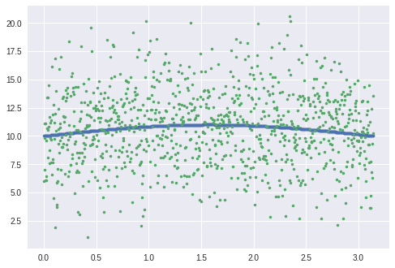

```python
t_first_1000 = t[0:1000]
N_first_1000 = N[0:1000]
bkgd_first_1000 = bkgd[0:1000]

fig, ax = plt.subplots(1,1)

ax.plot(t_first_1000, N_first_1000, '.')
ax.plot(t_first_1000, bkgd_first_1000, '.')
plt.show()
```

1b) Generalize your code so you can make a plot of any X contiguous points (e.g. 2000 points starting at point 500), and produce an example plot of a set of data somethere in the middle of your array.

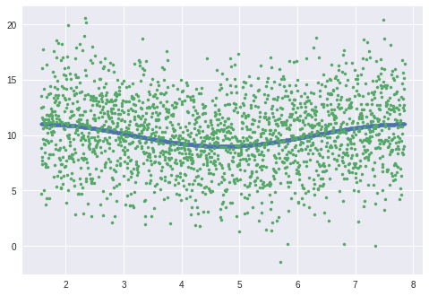

```python
num_points = 2000
slice_start = 500
slice_stop = slice_start + num_points

t_slice = t[slice_start:slice_stop]
N_slice = N[slice_start:slice_stop]
bkgd_slice = bkgd[slice_start:slice_stop]

fig, ax = plt.subplots(1,1)

ax.plot(t_slice, N_slice, '.')
ax.plot(t_slice, bkgd_slice, '.')

plt.show()
```

1c) Sometimes you want to sample the data, such as plotting every 100th point. Make a plot of the full data range, but only every 100th point.

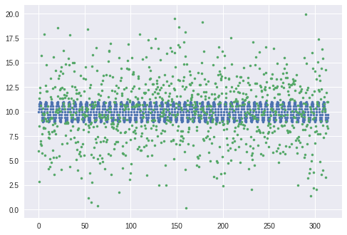

```python
sample_step = 100

t_step = t[0::sample_step]
N_step = N[0::sample_step]
bkgd_step = bkgd[0::sample_step]

fig, ax = plt.subplots(1,1)

ax.plot(t_step, N_step, '.')
ax.plot(t_step, bkgd_step, '.')
plt.show()
```

### Problem 2

2a) Make a 2d histogram plot. Read about options, and play with binsize so it is useful (too large a bin and everything washes out, too small and the sample noise dominates). Make sure you use a colorbar.

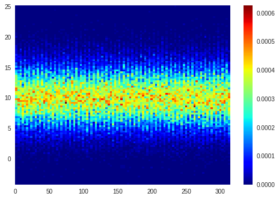

```python
fig, ax = plt.subplots(1,1)

plt.hist2d(t, bkgd, bins=(100, 100), cmap=plt.cm.jet, density=True)
plt.colorbar()
plt.show()
```

2b) Clearly explain what is being plotted in your plot (e.g. what does each color mean?)

- The probability of getting each value

### Problem 3: folding

3a) Make an new time variable that folds at a period of 2π (the modulo operator is your friend, variably expressed as mod(), %, or rem()). Then make a scatter plot of all your data, but now folded. (Reminder, for more data you'd never actually want to plot all the points.)

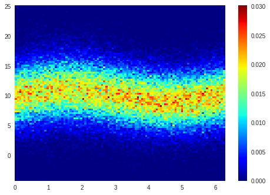

```python
t_fold = t % (2*np.pi)

fig, ax = plt.subplots(1,1)
plt.hist2d(t_fold, bkgd, bins=(100, 100), cmap=plt.cm.jet, density=True)
plt.colorbar()
plt.show()
```